# Effectiveness of Airbags – 1998 to 2010 in the US

John Maindonald, Statistics Research Associates

21 August 2023

# 1 An analysis based on crashes where there is a harmful event

The US National Highway Traffic Safety Administration (NHTSA) collects, using a random sampling method, data from all police-reported crashes in which there is a harmful event (people or property), and from which at least one vehicle is towed. The data frame () is derived from NHTSA data for the years 1997 – 2002.

Data collection used a complex sampling scheme in which the sampling fraction differs between observations. Each point has to be multiplied by the inverse of the relevant sampling fraction, to get a proper estimate of its contribution to the total number of accidents. The column ( = in the original SAS dataset) gives the relevant multiplier.

argue that on balance (over the period when their data were collected), airbags cost lives. After adjustment both for seatbelt use and for speed of impact, airbags appear on balance to be dangerous. The apparent effects, most serious in high impact accidents, are however at the level of statistical error.

Strictly, the conclusion is that, conditional on involvement in an accident that was sufficiently serious to be included in the database, and conditioning also on (seatbelt use or not) and (force of impact) there is a suggestion that airbags are harmful. Conditional on the airbag failing to prevent an outcome that is somewhat serious, there is a suggestion that airbags are harmful! Additionally, there are other factors on which the effects of airbag use could and likely should be conditioned.

Meyer and Finney’s analysis is open to serious challenge. argues that these data have too many uncertainties and sources of potential bias, including issues of what factors should be used for conditioning, to give reliable results.

# 2 The (Fatality Analysis Recording System (FARS) data

Farmer (2006) presented results from a different analysis that used used a data series that was designed to record outcomes from all accidents in which there was at least one fatality. Farmer used front seat passenger mortality, in cars without passenger airbags, as a standard against which to compare driver mortality. Limiting attention to cars with no passenger airbag, the analysis compares the ratio of driver mortality to passenger mortality between cars with a driver airbag and those without a driver airbag. An airbag is counted as available (really, potentially available) if a bag had at some previous time been installed. The breakdown, based on `availability,’ is designed to check the effectiveness of installing airbags into cars.

Annual data may be downloaded from . The url gives access to a web-based interface to the data from 2004. Results for 1998 are:

```r
library(gamclass)
tabAaDeaths <- tabFarsDead(dset=FARS)[['airbagAvail']]["1998", , ]
round(tabAaDeaths, 3)
```

```
             injury
D_airbagAvail P_injury D_injury  tot  prop
          no      1068      958 2026 0.897
          yes      211      136  347 0.645
```

Figure 2.1 shows the results graphically, for the years 1998 - 2010, based on data are taken from the dataset `gamclass::FARS`. Airbag availability data, which are the more relevant data, were not available for 2009 and 2010. Data are for frontal impact.

```r
cap1 <- 'With/without ratio of the ratio of driver death rates
  to passenger death rates:
  (a) w/wo driver airbag (not available for 2009 and 2010); (b) w/wo airbag deployment,
  (c) w/wo driver restraint (mainly seatbelt).'
```

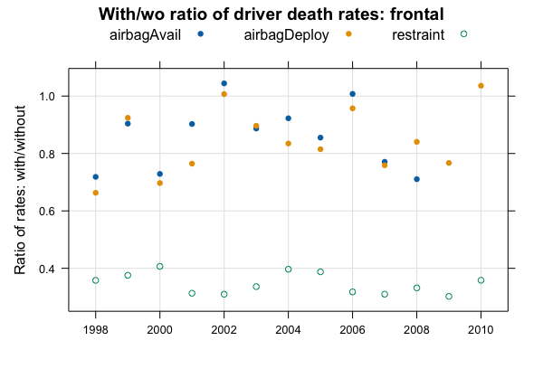

Figure 2.1: With/without ratio of the ratio of driver death rates to passenger death rates: (a) w/wo driver airbag (not available for 2009 and 2010); (b) w/wo airbag deployment, (c) w/wo driver restraint (mainly seatbelt).

```r
plotFars(tabDeaths=gamclass::frontDeaths,
          statistics = c("airbagAvail", "airbagDeploy", "restraint"))
```

# 3 Why not compare deployment with non-deployment

Airbags, if properly tuned, will deploy only when the risk of death is high. Comparison between accidents where bags deploy and accidents where they do not is at the same time, in part, a comparison between a low risk situation and a high risk situation – not a fair comparison.

# 4 Not all airbags are equal!

Airbags that meet current standards are designed to deploy only in accidents that appear serious enough, as e.g. measured by force of impact, that deployment is likely to do more good than harm. The 2008 result, where presence of an airbag gives a much lower ratio than deployment, is what might be expected if airbags deploy only in the most serious accidents, where the risk of death is anyway high. The 2002 and 2006 results may reflects problems with particular batches of airbags, such as led to the recall of Takata airbags. For the type of bags that have been the main focus of attention, long term exposure to heat and humidity could cause the ammonium nitrate used as propellant in these bags to explode. See https://www.nhtsa.gov/equipment/takata-recall-spotlight

# 5 Other factors

There may of course be effects from other factors on the driver to passenger death ratio. These can be checked – broad checks should be adequate in revealing anything of consequence.

Data for side and rear impact, and for under or over impact, show patterns that are much less clear. The relative death rates for side and rear deaths were both under 1.0 in 2008.

# 6 The above analyses make an important point

In Meyer’s analysis, there were many factors that could influence the risk of death – so many that the attempt to account for them all led to an analysis in which statistical noise made it impossible to reach useful conclusions about the parameter of interest. After adjusting for the effect of seatbelts, there were a number of other factors whose effects were similar to or greater than the airbag effect that was the chief interest of the analysis

A much simpler analysis was however possible, allowing an estimate that was pretty much unaffected by the factors that affected the death rate itself. This neatly avoided problems that, in the death count summary tables, arose from the need to account for many different factors.

Data summarization, or an equivalent use of regression methodology, cannot deliver a clear conclusion in cases where there are many different possible choices of the regression equation, and where the conclusion depends on the equation that is chosen. If an alternative is available that can avoid or largely avoid the need to account for many different explanatory variables, this is the preferred strategy.

Changes since 2008 in airbag design and in the mechanisms for triggering deployment mean that the results presented in Figure 2.1 have limited relevance to judging the effectiveness of airbags in use a decade or more later. The methodological issues that affect these analyses remain as important as ever. Papers that assess the impact of changes in airbag design and deployment include Braver, Shardell, and Teoh (2010) and Cummings and McKnight (2010). See also `?gamclass::FARS`.

# References

Braver, Elisa R, Michelle Shardell, and Eric R Teoh. 2010. “How Have Changes in Air Bag Designs Affected Frontal Crash Mortality?” *Annals of Epidemiology* 20 (7): 499–510.

Cummings, Peter, and Barbara McKnight. 2010. “Accounting for Vehicle, Crash, and Occupant Characteristics in Traffic Crash Studies.” *Injury Prevention* 16 (6): 363–66.